# Confidence Intervals Lab

```r
library(tidyverse)
library(janitor)
```

1 Introduction In this lab we’re going to draw multiple samples from a population, calculate a bootstrapped 95% CI for each, and then see how often the population parameter lies within the CI. Hopefully this will help you to understand what we mean by ‘confidence’:

‘If we draw 1000 repeated samples from a population, and form a 95% CI for each for a parameter estimate, then, on average, we are confident that approximately 950 CIs will contain the true population parameter, and approximately 50 will not. This is what we will try to show below.’

2. MVP Reading in the data & cleaning the variable names.

```r
ames_data <- read_csv("data/ames.csv") %>%
  clean_names()
```

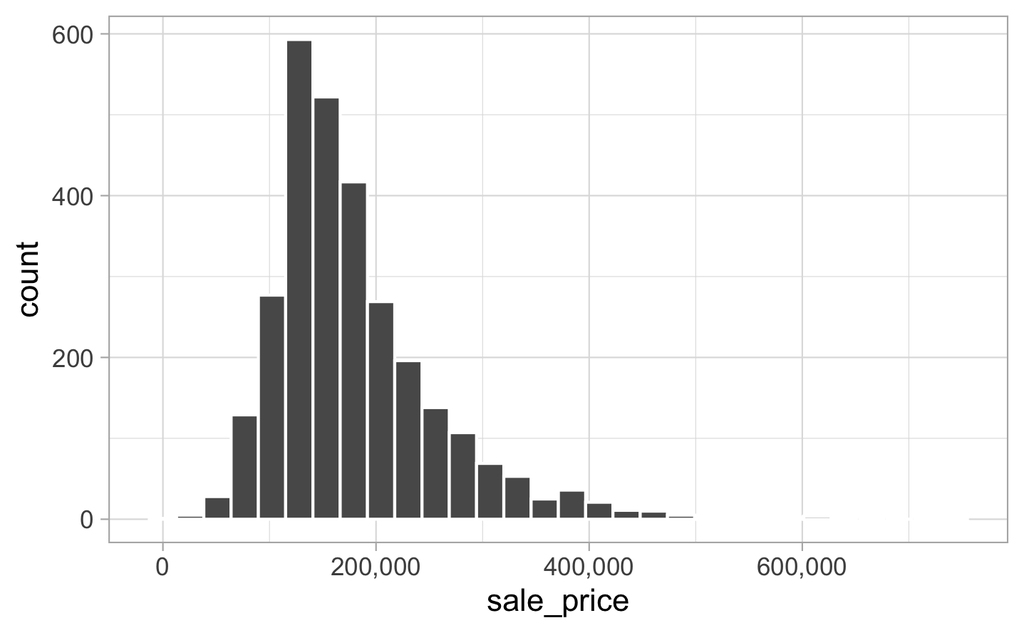

```r
#Plotting a histogram of sale_price to check if the distribution is normal.
library(stats)
ames_data %>%
  ggplot(aes(x = sale_price)) +
  geom_histogram(col = "white") +
  theme_light() +
  scale_x_continuous(labels = scales::comma)
```

```r
#The distribution is right skewed and unimodal.
```

4. Calculate the population parameter mean of sale_price. Store it in a variable, as we’ll need this value later when we check if each CI contains the parameter value or not.

```r
ames_pop <- ames_data %>%
  summarise(mean_sale_price = mean(sale_price))

ames_pop
```

| mean_sale_price |
| --- |
| 180796.1 |

5. Now we are going to:
1. take 1000 random samples each of size 100 from sale_price in ames
2. create a boostrap sampling distribution of mean(sale_price) from each 100-observation sample (use 1000 reps)
3. calculate the 95% CI for each bootstrap distribution
4. store the upper and lower bounds of the CI in a tibble called results

```r
library(infer)
#5i.
#Generating a sample size of 100 from sale_price in ames
sample_100 <- ames_data %>%
    rep_sample_n(size = 100, reps = 1) %>%
    ungroup() %>%
    select(sale_price)

sample_100
```

| sale_price |
| --- |
| 179900 |
| 196500 |
| 335000 |
| 211500 |
| 87000 |
| 184900 |
| 111500 |
| 117600 |
| 133000 |
| 200000 |

[output cut: 90 more lines]

```r
NA
```

```r
#5ii
#Creating a boostrap sampling distribution of mean(sale_price) from each 100-observation sample
bootstrap_100 <- sample_100 %>%
    specify(response = sale_price) %>%
    generate(reps = 1000, type = "bootstrap") %>%
    calculate(stat = "mean")

bootstrap_100
```

| replicate | stat |
| --- | --- |
| 1 | 191485.6 |
| 2 | 186808.7 |
| 3 | 193010.7 |
| 4 | 194929.1 |
| 5 | 181124.8 |
| 6 | 195014.8 |
| 7 | 207543.7 |
| 8 | 185148.5 |
| 9 | 175201.4 |
| 10 | 181809.9 |

[output cut: 990 more lines]

Calculating the 95% CI for each bootstrap distribution

```r
#5 iii
ci_95 <- bootstrap_100 %>%
    get_ci(level = 0.95, type = "percentile")

ci_95
```

| lower_ci | upper_ci |
| --- | --- |
| 174652.4 | 203450.5 |

4. Storing the upper and lower bounds of the CI in a tibble called results

```r
library(infer)
results <- tibble()
for (sample_num in 1:1000){

sample_100 <- ames_data %>%
    rep_sample_n(size = 100, reps = 1) %>%
    ungroup() %>%
    select(sale_price)

bootstrap_100 <- sample_100 %>%
    specify(response = sale_price) %>%
    generate(reps = 1000, type = "bootstrap") %>%
    calculate(stat = "mean")

ci_95 <- bootstrap_100 %>%
    get_ci(level = 0.95, type = "percentile")


ci_results <- c(
    sample_num = sample_num,
    lower = ci_95 %>%
      pull(lower_ci),
    upper = ci_95 %>%
      pull(upper_ci)
  )

results <- results %>%
    bind_rows(ci_results)
}
```

```r
#Visualising the sampling distribution and CI
bootstrap_100 %>%
  visualise(bins = 30) +
  shade_confidence_interval(endpoints = ci_95)
```

[output not shown]

```r
#Calculating the point estimate
#Sampling error is the point estimate - population parameter
bootstrap_100 %>%
  summarise(point_est = mean(stat))
```

[output not shown]

6. Pipe results to mutate() to add a new variable popn_param_in_ci which will be TRUE if the population parameter we calculated earlier is between lower and upper, and FALSE otherwise.

```r
results <- results %>%
  mutate(popn_param_in_ci = lower <= ames_pop$mean_sale_price & ames_pop$mean_sale_price <= upper)
```

6b. Perform an appropriate summarise() to determine the proportion of CIs that contain the population parameter. Our confidence level was 95% (equivalent to a proportion of 0.95). Is your proportion close to that value?

```r
results %>%
  summarise(proportion_CI_containing_popn_param = mean(popn_param_in_ci))
```

| proportion_CI_containing_popn_param |
| --- |
| 0.954 |